# 1. Wstęp

## 1.1. Załadowanie bibliotek, definicje stałych i funkcji pomocniczych

```python
import time
import math
import pandas as pd
import numpy as np
import matplotlib.pyplot as plt
import seaborn as sns
from IPython.core.display import display, HTML
from scipy import stats, special
from sklearn.impute import SimpleImputer
from sklearn.preprocessing import StandardScaler, OneHotEncoder
from sklearn.compose import ColumnTransformer
from sklearn.pipeline import Pipeline
from datetime import datetime

from sklearn import (
    model_selection,
    metrics,
    linear_model,
    ensemble,
    tree,
    gaussian_process,
    neighbors,
    kernel_ridge,
    svm,
    neural_network,
    cross_decomposition,
    compose,
)


# FILE_NAME = "files/downloaded_28_09_20/prepared.csv"
FILE_NAME = "files/downloaded_11.10.2020/prepared.csv"

UNUSED_COLUMNS = [
    'record_id',
#     'sid',
    'timestamp',
#     'deck_name',
    'question',
    'answer',
    'question_fields',
    'answer_fields',
    'note_type',
    'due',
    'answered_at',

    # temporarily
    'q_lang', 'q_lang_name', 'a_lang', 'a_lang_name'
]

CATEGORY_COLUMNS = [
    'model_type',
    'type',
    'new_type',
    'queue',
    'new_queue',
    'part_of_day',
    'weekday',
]

NUMERICAL_COLUMNS = [
    'ease',
    'reps',
    'time_taken',
    'grade_time',
    'total_study_time',
    'last_interval'
]

BOOLEAN_COLUMNS = [
    'question_has_cloze',
    'question_has_type_in',
    'question_has_type_in_cloze',
    'question_has_sound',
    'answer_has_sound',
    'question_has_video',
    'answer_has_video',
    'question_has_image',
    'answer_has_image'
]

# Y
Y_COLUMN = "ESTIMATED_INTERVAL"


def get_outliers(data_frame, attribute):
    series = data_frame[attribute]
    iqr = stats.iqr(series)
    q1 = series.quantile(0.25)
    q3 = series.quantile(0.75)
    return data_frame[(series <= (q1 - 1.5*iqr)) | (series >= (q3 + 1.5*iqr))]
```

## 1.2 Wczytanie i wstępne przygotowanie zbioru danych

1. Wczytanie zbioru danych z pliku
2. Odrzucenie niepotrzebnych kolumn
3. Konwersja odpowiednich kolumn na typ `category`

```python
# Load dataset
df = pd.read_csv(FILE_NAME)

# Drop unused columns
df = df.drop(columns=UNUSED_COLUMNS)

# Convert some columns to category
for col in CATEGORY_COLUMNS:
    df[col] = df[col].astype('category')
```

## 1.3. Podział zbioru na zbiór danych

Zbiór danych jest dzielony na osobne zbiory: **dane numeryczne** oraz **dane kategoryczne**. Wyodrębniane jest również "wyjście", czyli **zbiór Y**.

```python
Y = df[[Y_COLUMN]]
X_cat = df[CATEGORY_COLUMNS]
X_num = df[NUMERICAL_COLUMNS]
X_bool = df[BOOLEAN_COLUMNS]
```

# 2. Uczenie na nieprzygotowanych danych

Dane numeryczne nie zostały w żaden sposób przygotowane. Dane kategoryczne zostały jedynie zakodowane metodą "One-hot" ("kod 1 z n"), a wartości Prawda-Fałsz zmienione na cyfry 1-0.

## 2.1 Kodowanie One-Hot

```python
# Encode categories with One-Hot Encoder
encoder = OneHotEncoder(handle_unknown='ignore')
one_hot_categories = encoder.fit_transform(X_cat).toarray()

# Make names for new columns by concatenating category names with each of the value
new_categories = []
for i, category_name in enumerate(CATEGORY_COLUMNS):
    for category_value in encoder.categories_[i]:
        new_categories.append(category_name + "_" + str(category_value))

# Replace old X_cat DataFrame with a new, one-hot-encoded DataFrame
X_cat = pd.DataFrame(one_hot_categories, columns=new_categories)

display(X_cat)
```

|  | model_type_CLOZE | model_type_STANDARD | type_learning | type_new | type_relearning | type_review | new_type_learning | new_type_relearning | new_type_review | queue_day_learn_relearn | ... | part_of_day_midday | part_of_day_morning | part_of_day_night | weekday_friday | weekday_monday | weekday_saturday | weekday_sunday | weekday_thursday | weekday_tuesday | weekday_wednesday |
| --- | --- | --- | --- | --- | --- | --- | --- | --- | --- | --- | --- | --- | --- | --- | --- | --- | --- | --- | --- | --- | --- |
| 0 | 0.0 | 1.0 | 0.0 | 0.0 | 0.0 | 1.0 | 0.0 | 0.0 | 1.0 | 0.0 | ... | 0.0 | 0.0 | 0.0 | 0.0 | 0.0 | 0.0 | 1.0 | 0.0 | 0.0 | 0.0 |
| 1 | 0.0 | 1.0 | 0.0 | 0.0 | 0.0 | 1.0 | 0.0 | 0.0 | 1.0 | 0.0 | ... | 0.0 | 0.0 | 0.0 | 0.0 | 0.0 | 0.0 | 1.0 | 0.0 | 0.0 | 0.0 |
| 2 | 0.0 | 1.0 | 0.0 | 0.0 | 0.0 | 1.0 | 0.0 | 0.0 | 1.0 | 0.0 | ... | 0.0 | 0.0 | 0.0 | 0.0 | 0.0 | 0.0 | 1.0 | 0.0 | 0.0 | 0.0 |
| 3 | 0.0 | 1.0 | 0.0 | 0.0 | 0.0 | 1.0 | 0.0 | 0.0 | 1.0 | 0.0 | ... | 0.0 | 0.0 | 0.0 | 0.0 | 0.0 | 0.0 | 1.0 | 0.0 | 0.0 | 0.0 |
| 4 | 0.0 | 1.0 | 0.0 | 0.0 | 0.0 | 1.0 | 0.0 | 0.0 | 1.0 | 0.0 | ... | 0.0 | 0.0 | 0.0 | 0.0 | 0.0 | 0.0 | 1.0 | 0.0 | 0.0 | 0.0 |
| ... | ... | ... | ... | ... | ... | ... | ... | ... | ... | ... | ... | ... | ... | ... | ... | ... | ... | ... | ... | ... | ... |
| 36391 | 1.0 | 0.0 | 0.0 | 0.0 | 0.0 | 1.0 | 0.0 | 0.0 | 1.0 | 0.0 | ... | 1.0 | 0.0 | 0.0 | 0.0 | 0.0 | 0.0 | 1.0 | 0.0 | 0.0 | 0.0 |
| 36392 | 1.0 | 0.0 | 0.0 | 0.0 | 0.0 | 1.0 | 0.0 | 0.0 | 1.0 | 0.0 | ... | 1.0 | 0.0 | 0.0 | 0.0 | 0.0 | 0.0 | 1.0 | 0.0 | 0.0 | 0.0 |
| 36393 | 1.0 | 0.0 | 0.0 | 0.0 | 0.0 | 1.0 | 0.0 | 0.0 | 1.0 | 0.0 | ... | 1.0 | 0.0 | 0.0 | 0.0 | 0.0 | 0.0 | 1.0 | 0.0 | 0.0 | 0.0 |
| 36394 | 0.0 | 1.0 | 0.0 | 0.0 | 0.0 | 1.0 | 0.0 | 0.0 | 1.0 | 0.0 | ... | 1.0 | 0.0 | 0.0 | 0.0 | 0.0 | 0.0 | 1.0 | 0.0 | 0.0 | 0.0 |
| 36395 | 0.0 | 1.0 | 0.0 | 0.0 | 1.0 | 0.0 | 0.0 | 0.0 | 1.0 | 0.0 | ... | 1.0 | 0.0 | 0.0 | 0.0 | 0.0 | 0.0 | 1.0 | 0.0 | 0.0 | 0.0 |

36396 rows × 29 columns

## 2.2 Konwersja wartości Prawda-Fałsz

```python
X_bool = X_bool.astype("int64")
display(X_bool)
```

|  | question_has_cloze | question_has_type_in | question_has_type_in_cloze | question_has_sound | answer_has_sound | question_has_video | answer_has_video | question_has_image | answer_has_image |
| --- | --- | --- | --- | --- | --- | --- | --- | --- | --- |
| 0 | 0 | 0 | 0 | 0 | 1 | 0 | 0 | 0 | 1 |
| 1 | 0 | 0 | 0 | 0 | 0 | 0 | 0 | 0 | 1 |
| 2 | 0 | 0 | 0 | 0 | 1 | 0 | 0 | 0 | 1 |
| 3 | 0 | 0 | 0 | 0 | 1 | 0 | 0 | 0 | 1 |
| 4 | 0 | 0 | 0 | 0 | 1 | 0 | 0 | 0 | 1 |
| ... | ... | ... | ... | ... | ... | ... | ... | ... | ... |
| 36391 | 1 | 0 | 0 | 0 | 0 | 0 | 0 | 0 | 0 |
| 36392 | 1 | 0 | 0 | 0 | 0 | 0 | 0 | 0 | 0 |
| 36393 | 1 | 0 | 0 | 0 | 0 | 0 | 0 | 0 | 0 |
| 36394 | 0 | 0 | 0 | 0 | 0 | 0 | 0 | 0 | 1 |
| 36395 | 0 | 0 | 0 | 0 | 0 | 0 | 0 | 0 | 0 |

36396 rows × 9 columns

## 2.3 Połączenie zbiórów w jeden i podzielenie go na zbiory treningowy i testowy

```python
X = pd.concat([X_num, X_cat, X_bool], axis=1)

df_train, df_test = model_selection.train_test_split(
    pd.concat([X, Y], axis=1),
    random_state=0,
    test_size=.3
)

X_train = df_train.drop(Y_COLUMN, axis=1)
X_test = df_test.drop(Y_COLUMN, axis=1)

Y_train = df_train[Y_COLUMN]
Y_test = df_test[Y_COLUMN]
```

## 2.4 Uczenie za pomocą kilku modeli

Zdefiniowanie listy modeli:

```python
models = [
    ("ARDRegression", linear_model.ARDRegression()),
    ("AdaBoostRegressor", ensemble.AdaBoostRegressor()),
    ("BaggingRegressor", ensemble.BaggingRegressor()),
    ("DecisionTreeRegressor", tree.DecisionTreeRegressor()),
    ("ElasticNet", linear_model.ElasticNet()),
    ("ElasticNetCV", linear_model.ElasticNetCV()),
    ("ExtraTreeRegressor", tree.ExtraTreeRegressor()),
    ("ExtraTreesRegressor", ensemble.ExtraTreesRegressor()),
    ("HuberRegressor", linear_model.HuberRegressor()),
    ("KNeighborsRegressor", neighbors.KNeighborsRegressor()),
    ("Lasso", linear_model.Lasso()),
    ("LassoCV", linear_model.LassoCV()),
    ("MLPRegressor", neural_network.MLPRegressor()),
    ("NuSVR", svm.NuSVR()),
    ("OrthogonalMatchingPursuit", linear_model.OrthogonalMatchingPursuit()),
    ("OrthogonalMatchingPursuitCV", linear_model.OrthogonalMatchingPursuitCV()),
    ("PLSRegression", cross_decomposition.PLSRegression()),
    ("PassiveAggressiveRegressor", linear_model.PassiveAggressiveRegressor()),
    ("RANSACRegressor", linear_model.RANSACRegressor()),
    ("RadiusNeighborsRegressor", neighbors.RadiusNeighborsRegressor()),
    ("RandomForestRegressor", ensemble.RandomForestRegressor()),
    ("Ridge", linear_model.Ridge()),
    ("RidgeCV", linear_model.RidgeCV()),
    ("SGDRegressor", linear_model.SGDRegressor()),
    ("SVR", svm.SVR()),
    ("TheilSenRegressor", linear_model.TheilSenRegressor()),
]
```

```python
def learn_predict(models_, X_train_, X_test_, Y_train_, Y_test_):
    results_test_ = pd.DataFrame(columns=['method', 'r2_score', 'explained_variance', 'MSE'])
    results_train_ = pd.DataFrame(columns=['method', 'r2_score', 'explained_variance','MSE'])

    for name, model in models_:
        start = time.time()
        model.fit(X_train_.copy(), Y_train_.copy())
        print(name + ": " + str(time.time()-start) + "s")
        predictions_test = model.predict(X_test_.copy())
        predictions_train = model.predict(X_train_.copy())

        results_test_ = results_test_.append({
            'method': name,
            'r2_score': metrics.r2_score(Y_test_, predictions_test),
            'explained_variance': metrics.explained_variance_score(Y_test_, predictions_test),
            'MSE': metrics.mean_squared_error(Y_test_, predictions_test),
        }, ignore_index=True)

        results_train_ = results_train_.append({
            'method': name,
            'r2_score': metrics.r2_score(Y_train_, predictions_train),
            'explained_variance': metrics.explained_variance_score(Y_train_, predictions_train),
            'MSE': metrics.mean_squared_error(Y_train_, predictions_train),
        }, ignore_index=True)

    return results_test_, results_train_
```

```python
results_test, results_train = learn_predict(models, X_train, X_test, Y_train, Y_test)
```

```
ARDRegression: 3.7487118244171143s
AdaBoostRegressor: 1.239349603652954s
BaggingRegressor: 1.0424187183380127s
DecisionTreeRegressor: 0.16550827026367188s
ElasticNet: 0.018009185791015625s
ElasticNetCV: 0.259796142578125s
ExtraTreeRegressor: 0.10600852966308594s
ExtraTreesRegressor: 6.7034711837768555s
HuberRegressor: 0.7238104343414307s
KNeighborsRegressor: 0.12222957611083984s
Lasso: 0.05091404914855957s
LassoCV: 0.26726865768432617s
MLPRegressor: 20.479326486587524s
NuSVR: 53.306307792663574s
OrthogonalMatchingPursuit: 0.012071847915649414s
OrthogonalMatchingPursuitCV: 0.10567259788513184s
PLSRegression: 0.023725032806396484s
PassiveAggressiveRegressor: 0.05818653106689453s
RANSACRegressor: 0.18758726119995117s
RadiusNeighborsRegressor: 0.13734197616577148s
RandomForestRegressor: 10.708926439285278s
Ridge: 0.018384456634521484s
RidgeCV: 0.0938577651977539s
SGDRegressor: 0.14792680740356445s
SVR: 46.26370358467102s
TheilSenRegressor: 5.373316049575806s
```

```python
pd.options.display.float_format = '{:,.4f}'.format
display(HTML("<hr><h2>Test:</h2>"))
display(results_test.sort_values(["r2_score", "explained_variance", "MSE"], ascending=False))
display(HTML("<hr><h2>Train:</h2>"))
display(results_train.sort_values(["r2_score", "explained_variance", "MSE"], ascending=False))
```

Test:

|  | method | r2_score | explained_variance | MSE |
| --- | --- | --- | --- | --- |
| 7 | ExtraTreesRegressor | 0.9515 | 0.9515 | 3,410.8002 |
| 20 | RandomForestRegressor | 0.9244 | 0.9244 | 5,321.0349 |
| 6 | ExtraTreeRegressor | 0.9071 | 0.9071 | 6,537.2010 |
| 2 | BaggingRegressor | 0.8929 | 0.8929 | 7,537.1754 |
| 3 | DecisionTreeRegressor | 0.8913 | 0.8913 | 7,648.8586 |
| 12 | MLPRegressor | 0.7053 | 0.7069 | 20,735.5968 |
| 22 | RidgeCV | 0.6562 | 0.6562 | 24,190.0893 |
| 21 | Ridge | 0.6560 | 0.6560 | 24,205.2936 |
| 0 | ARDRegression | 0.6553 | 0.6553 | 24,258.4078 |
| 10 | Lasso | 0.6519 | 0.6519 | 24,493.8911 |
| 15 | OrthogonalMatchingPursuitCV | 0.6427 | 0.6427 | 25,142.6198 |
| 14 | OrthogonalMatchingPursuit | 0.6380 | 0.6380 | 25,472.6230 |
| 4 | ElasticNet | 0.6300 | 0.6300 | 26,038.6975 |
| 25 | TheilSenRegressor | 0.5849 | 0.5859 | 29,208.7183 |
| 16 | PLSRegression | 0.5779 | 0.5779 | 29,704.1490 |
| 11 | LassoCV | 0.5311 | 0.5311 | 32,994.2502 |
| 18 | RANSACRegressor | 0.5304 | 0.5314 | 33,044.1086 |
| 5 | ElasticNetCV | 0.5299 | 0.5299 | 33,079.2540 |
| 8 | HuberRegressor | 0.5188 | 0.5243 | 33,863.1278 |
| 17 | PassiveAggressiveRegressor | 0.4932 | 0.5006 | 35,661.0241 |
| 1 | AdaBoostRegressor | 0.4578 | 0.6581 | 38,156.8529 |
| 9 | KNeighborsRegressor | 0.2990 | 0.3019 | 49,328.9779 |
| 13 | NuSVR | -0.0534 | 0.0014 | 74,129.4872 |
| 24 | SVR | -0.0788 | 0.0019 | 75,918.4207 |
| 19 | RadiusNeighborsRegressor | -0.0985 | -0.1654 | 77,298.7222 |
| 23 | SGDRegressor | -103,551,320,484,076,263,270,573,408,256.0000 | -88,279,904,013,196,445,602,788,933,632.0000 | 7,286,947,561,948,328,349,497,430,022,029,312.0000 |

Train:

|  | method | r2_score | explained_variance | MSE |
| --- | --- | --- | --- | --- |
| 3 | DecisionTreeRegressor | 1.0000 | 1.0000 | 0.0000 |
| 6 | ExtraTreeRegressor | 1.0000 | 1.0000 | 0.0000 |
| 7 | ExtraTreesRegressor | 1.0000 | 1.0000 | 0.0000 |
| 19 | RadiusNeighborsRegressor | 1.0000 | 1.0000 | 0.0000 |
| 20 | RandomForestRegressor | 0.9864 | 0.9864 | 1,223.5094 |
| 2 | BaggingRegressor | 0.9644 | 0.9644 | 3,207.6838 |
| 1 | AdaBoostRegressor | 0.6024 | 0.7648 | 35,822.0635 |
| 12 | MLPRegressor | 0.5982 | 0.5992 | 36,204.2784 |
| 9 | KNeighborsRegressor | 0.5221 | 0.5240 | 43,058.2735 |
| 21 | Ridge | 0.5186 | 0.5186 | 43,373.4995 |
| 22 | RidgeCV | 0.5186 | 0.5186 | 43,376.9072 |
| 0 | ARDRegression | 0.5177 | 0.5177 | 43,457.7279 |
| 10 | Lasso | 0.5126 | 0.5126 | 43,916.5656 |
| 15 | OrthogonalMatchingPursuitCV | 0.5076 | 0.5076 | 44,366.4693 |
| 14 | OrthogonalMatchingPursuit | 0.5029 | 0.5029 | 44,792.2339 |
| 4 | ElasticNet | 0.4910 | 0.4910 | 45,866.6176 |
| 16 | PLSRegression | 0.4475 | 0.4475 | 49,784.2333 |
| 25 | TheilSenRegressor | 0.4101 | 0.4108 | 53,152.0846 |
| 11 | LassoCV | 0.4030 | 0.4030 | 53,797.5411 |
| 18 | RANSACRegressor | 0.4023 | 0.4033 | 53,852.8179 |
| 5 | ElasticNetCV | 0.4016 | 0.4016 | 53,921.9157 |
| 8 | HuberRegressor | 0.3918 | 0.3964 | 54,799.0599 |
| 17 | PassiveAggressiveRegressor | 0.3762 | 0.3821 | 56,205.3809 |
| 13 | NuSVR | -0.0419 | 0.0012 | 93,881.4483 |
| 24 | SVR | -0.0618 | 0.0016 | 95,675.6102 |
| 23 | SGDRegressor | -50,810,784,946,724,501,613,174,587,392.0000 | -39,521,146,777,586,005,595,450,769,408.0000 | 4,578,373,242,045,271,530,267,644,344,139,776.0000 |

# 3. Korekta danych

Korekta danych polegać będzie na:

1. Usunięciu wartości odstających
2. Usunięciu atrybutów mających mały wpływ na wynik (lub całkowity brak wpływu)
3. Standaryzacji

Żeby tego dokonać, wcześniej należy zbadać rozkład danych

## 3.1 Badanie rozkładu danych

### 2.3.1 Rozkład danych numerycznych

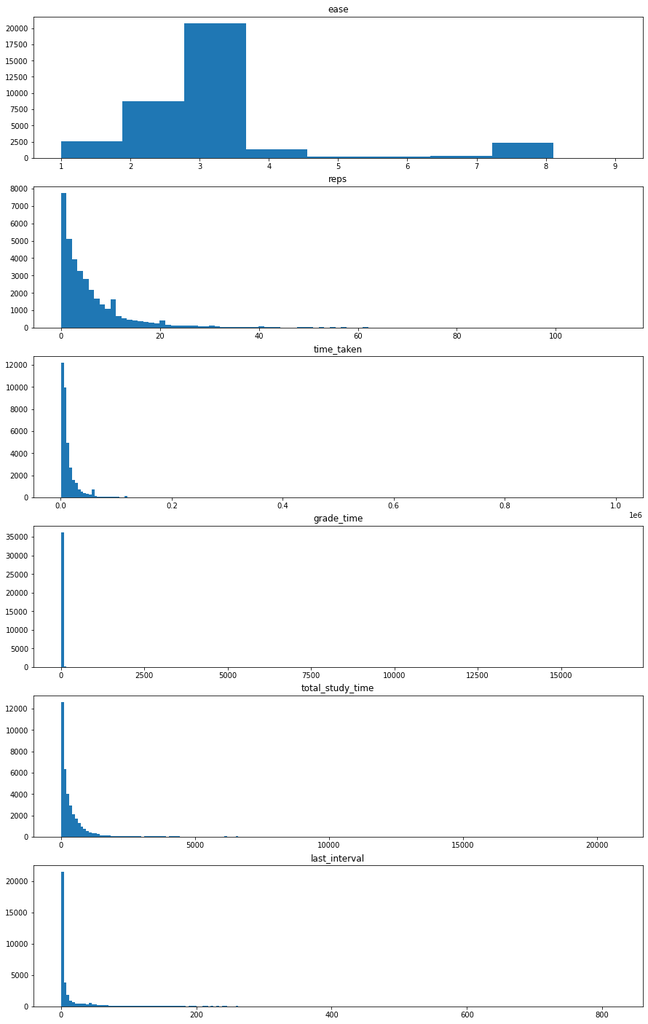

```python
f, axes = plt.subplots(len(NUMERICAL_COLUMNS), 1, figsize=(15,25))
ax = axes.ravel()

for i, attribute in enumerate(NUMERICAL_COLUMNS):
    ax[i].set_title(attribute)
    ax[i].hist(
        X_num[attribute],
        bins=min(X_num[attribute].unique().size, 200)
    )

plt.show()
```

### 3.1.2 Rozkład danych kategorycznych

```python
%%javascript
IPython.OutputArea.auto_scroll_threshold = 200;
```

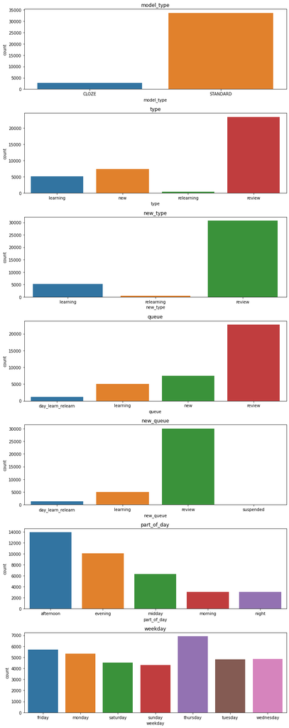

```python
f, axes = plt.subplots(len(CATEGORY_COLUMNS), 1, figsize=(10,25))
ax = axes.ravel()

X_cat_original = df[CATEGORY_COLUMNS]

for i, attribute in enumerate(CATEGORY_COLUMNS):
    ax[i].set_title(attribute)
    sns.countplot(x=attribute, data=X_cat_original, ax=ax[i])

plt.tight_layout()
plt.show()
```

### 3.1.3 Rozkład danych prawda-fałsz

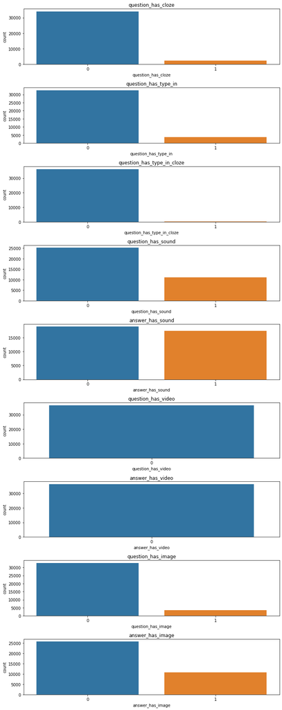

```python
f, axes = plt.subplots(len(BOOLEAN_COLUMNS), 1, figsize=(10,25))
ax = axes.ravel()

for i, attribute in enumerate(BOOLEAN_COLUMNS):
    ax[i].set_title(attribute)
    sns.countplot(x=attribute, data=X_bool, ax=ax[i])

plt.tight_layout()
plt.show()
```

### 3.1.4 Rozkład danych wyjściowych Y

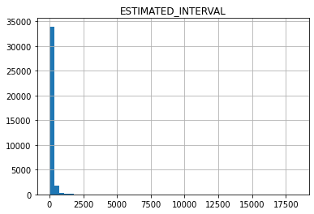

```python
_ = Y.hist(bins=50)
```

## 3.2 Transformacja danych numerycznych

Na powyższych wykresach dla danych numerycznych widać, że prawie wszystkie z nich (oprócz `ease`) posiadają rozkład wykładniczy. Taki rozkład danych jest nieco trudniejszy do analizy niż rozkład normalny. Trudniej jest zaobserwować wartości odstajace, a ponadto, niektóre z modeli regresyjnych zakładają że dane będą miały rozkład normalny.

W związku z tym, użyję przekształcenia Boxa-Coxa, aby zbliżyć rozkład do normalnego.

```python
num_columns = [x for x in NUMERICAL_COLUMNS if x != "ease"]

X_bc = X.copy()
bc_lambdas = {}
for column in num_columns:
    try:
        bc_values, lmbda = stats.boxcox(X_num[column])
    except ValueError:
        bc_values, lmbda = stats.boxcox(X_num[column]+1)

    X_bc[column] = pd.Series(bc_values)
    bc_lambdas[column] = lmbda

Y_bc = Y.copy()
bc_values, lmbda = stats.boxcox(Y[Y_COLUMN] + 1)
Y_bc[Y_COLUMN] = pd.Series(bc_values)
bc_lambdas[Y_COLUMN] = lmbda

display(bc_lambdas)
display(X_bc)
```

```
{'reps': -0.3648785681514888,
 'time_taken': -0.18616925440445248,
 'grade_time': -0.085498310172545,
 'total_study_time': 0.0567088172892652,
 'last_interval': -0.2990905923546863,
 'ESTIMATED_INTERVAL': -0.1702465439135482}
```

|  | ease | reps | time_taken | grade_time | total_study_time | last_interval | model_type_CLOZE | model_type_STANDARD | type_learning | type_new | ... | weekday_wednesday | question_has_cloze | question_has_type_in | question_has_type_in_cloze | question_has_sound | answer_has_sound | question_has_video | answer_has_video | question_has_image | answer_has_image |
| --- | --- | --- | --- | --- | --- | --- | --- | --- | --- | --- | --- | --- | --- | --- | --- | --- | --- | --- | --- | --- | --- |
| 0 | 3 | 1.557670 | 4.429165 | 0.998100 | 2.616497 | 2.617415 | 0.0 | 1.0 | 0.0 | 0.0 | ... | 0.0 | 0 | 0 | 0 | 0 | 1 | 0 | 0 | 0 | 1 |
| 1 | 2 | 0.612439 | 4.470952 | 2.350529 | 2.897798 | 0.626016 | 0.0 | 1.0 | 0.0 | 0.0 | ... | 0.0 | 0 | 0 | 0 | 0 | 0 | 0 | 0 | 0 | 1 |
| 2 | 3 | 1.694343 | 4.279061 | 0.804435 | 3.256949 | 2.575888 | 0.0 | 1.0 | 0.0 | 0.0 | ... | 0.0 | 0 | 0 | 0 | 0 | 1 | 0 | 0 | 0 | 1 |
| 3 | 3 | 1.557670 | 4.173741 | -0.732236 | 3.433230 | 2.693577 | 0.0 | 1.0 | 0.0 | 0.0 | ... | 0.0 | 0 | 0 | 0 | 0 | 1 | 0 | 0 | 0 | 1 |
| 4 | 3 | 1.315290 | 3.989689 | -1.068884 | 3.507626 | 1.277414 | 0.0 | 1.0 | 0.0 | 0.0 | ... | 0.0 | 0 | 0 | 0 | 0 | 1 | 0 | 0 | 0 | 1 |
| ... | ... | ... | ... | ... | ... | ... | ... | ... | ... | ... | ... | ... | ... | ... | ... | ... | ... | ... | ... | ... | ... |
| 36391 | 3 | 2.027302 | 4.517686 | -0.186589 | 5.441754 | 2.451768 | 1.0 | 0.0 | 0.0 | 0.0 | ... | 0.0 | 1 | 0 | 0 | 0 | 0 | 0 | 0 | 0 | 0 |
| 36392 | 2 | 2.027302 | 3.956492 | -0.158997 | 5.486450 | 2.451768 | 1.0 | 0.0 | 0.0 | 0.0 | ... | 0.0 | 1 | 0 | 0 | 0 | 0 | 0 | 0 | 0 | 0 |
| 36393 | 3 | 2.196482 | 4.366370 | -0.912481 | 5.573444 | 1.134819 | 1.0 | 0.0 | 0.0 | 0.0 | ... | 0.0 | 1 | 0 | 0 | 0 | 0 | 0 | 0 | 0 | 0 |
| 36394 | 3 | 1.744099 | 4.311275 | -0.302168 | 5.635924 | 2.146328 | 0.0 | 1.0 | 0.0 | 0.0 | ... | 0.0 | 0 | 0 | 0 | 0 | 0 | 0 | 0 | 0 | 1 |
| 36395 | 3 | 1.598102 | 4.360959 | 0.525551 | 5.712150 | 0.000000 | 0.0 | 1.0 | 0.0 | 0.0 | ... | 0.0 | 0 | 0 | 0 | 0 | 0 | 0 | 0 | 0 | 0 |

36396 rows × 44 columns

## 3.3 Nowy rozkład danych i wartości odstające

Nowy rozkład wygląda następująco. Czerwone przerywane linie oznaczają granicę wartości nie-odstających. Wartości nie mieszczące się w wyznaczonym zakresie będę traktował jako wartości odstające i usunę je ze zbioru.

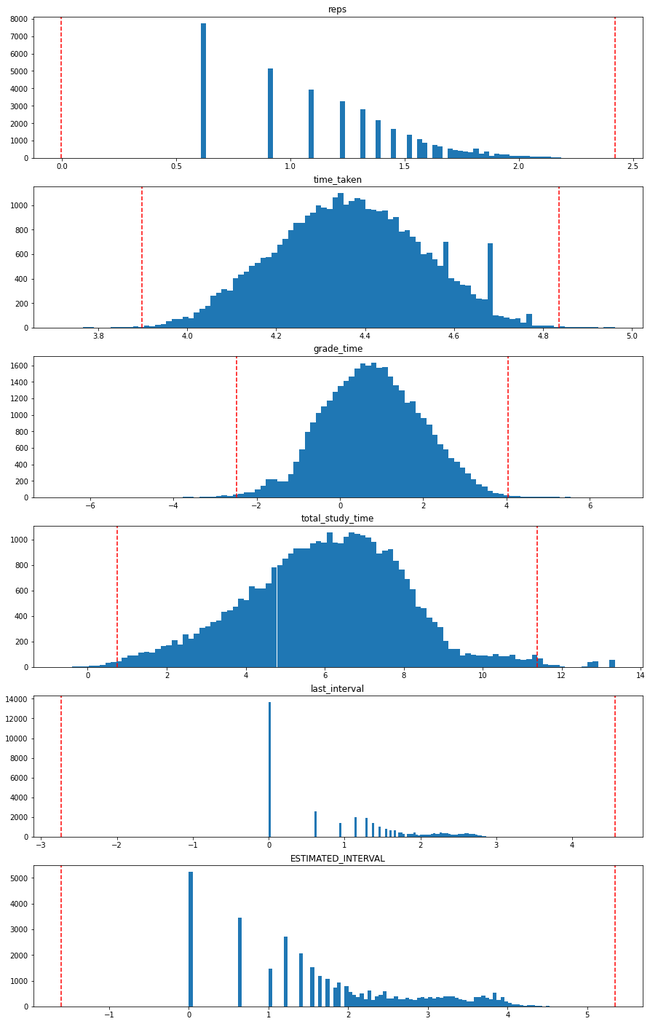

```python
columns = num_columns + [Y_COLUMN]
f, axes = plt.subplots(len(columns), 1, figsize=(15,25))
ax = axes.ravel()

tmp_df = pd.concat([X_bc, Y_bc], axis=1)


for i, attribute in enumerate(columns):
    series = tmp_df[attribute]
    ax[i].set_title(attribute)
    ax[i].hist(series, bins=min(series.unique().size, 100))

    iqr = stats.iqr(series)
    q1 = series.quantile(0.25)
    q3 = series.quantile(0.75)

    # red dashed lines indicating outliers range
    ax[i].axvline(q1 - 1.5*iqr, color='r', linestyle='dashed')
    ax[i].axvline(q3 + 1.5*iqr, color='r', linestyle='dashed')

plt.show()
```

Z rozkładu wartości dla poszczególnych atrybutów możemy zauważyć, że niektóre z atrybutów zawierają wartości odstające.

W tej części zbadam wartości odstające oraz ich źródło pochodzenia i na tej podstawię zdecyduję, czy należy wiersze w których się znajdują usunąć ze zbioru.

#### 3.3.1 `reps`

Atrybut określający liczbę powtórzeń danej karty. Po transformacji rozkładu oryginalnego do postaci zbliżonej do rozkładu normalnego, można zauważyć, że nie występują wartości odstające.

```python
print(get_outliers(X_bc, 'reps').shape[0])
```

```
0
```

#### 3.3.2 `time_taken`

Atrybut ten oznacza czas jaki użytkownikowi zajęło odpowiedzenie na pytanie. W tym przypadku można zaobserwować występowanie wartości odstających.

```python
outliers = get_outliers(X_bc, 'time_taken')
print(outliers.shape[0])
```

```
107
```

Rekordy zawierające wartości odstajace zostaną usunięte:

```python
X_num_clean = X_bc.copy()
X_num_clean = X_num_clean.drop(outliers.index)
```

```python
X_num_clean
```

|  | ease | reps | time_taken | grade_time | total_study_time | last_interval | model_type_CLOZE | model_type_STANDARD | type_learning | type_new | ... | weekday_wednesday | question_has_cloze | question_has_type_in | question_has_type_in_cloze | question_has_sound | answer_has_sound | question_has_video | answer_has_video | question_has_image | answer_has_image |
| --- | --- | --- | --- | --- | --- | --- | --- | --- | --- | --- | --- | --- | --- | --- | --- | --- | --- | --- | --- | --- | --- |
| 0 | 3 | 1.557670 | 4.429165 | 0.998100 | 2.616497 | 2.617415 | 0.0 | 1.0 | 0.0 | 0.0 | ... | 0.0 | 0 | 0 | 0 | 0 | 1 | 0 | 0 | 0 | 1 |
| 1 | 2 | 0.612439 | 4.470952 | 2.350529 | 2.897798 | 0.626016 | 0.0 | 1.0 | 0.0 | 0.0 | ... | 0.0 | 0 | 0 | 0 | 0 | 0 | 0 | 0 | 0 | 1 |
| 2 | 3 | 1.694343 | 4.279061 | 0.804435 | 3.256949 | 2.575888 | 0.0 | 1.0 | 0.0 | 0.0 | ... | 0.0 | 0 | 0 | 0 | 0 | 1 | 0 | 0 | 0 | 1 |
| 3 | 3 | 1.557670 | 4.173741 | -0.732236 | 3.433230 | 2.693577 | 0.0 | 1.0 | 0.0 | 0.0 | ... | 0.0 | 0 | 0 | 0 | 0 | 1 | 0 | 0 | 0 | 1 |
| 4 | 3 | 1.315290 | 3.989689 | -1.068884 | 3.507626 | 1.277414 | 0.0 | 1.0 | 0.0 | 0.0 | ... | 0.0 | 0 | 0 | 0 | 0 | 1 | 0 | 0 | 0 | 1 |
| ... | ... | ... | ... | ... | ... | ... | ... | ... | ... | ... | ... | ... | ... | ... | ... | ... | ... | ... | ... | ... | ... |
| 36391 | 3 | 2.027302 | 4.517686 | -0.186589 | 5.441754 | 2.451768 | 1.0 | 0.0 | 0.0 | 0.0 | ... | 0.0 | 1 | 0 | 0 | 0 | 0 | 0 | 0 | 0 | 0 |
| 36392 | 2 | 2.027302 | 3.956492 | -0.158997 | 5.486450 | 2.451768 | 1.0 | 0.0 | 0.0 | 0.0 | ... | 0.0 | 1 | 0 | 0 | 0 | 0 | 0 | 0 | 0 | 0 |
| 36393 | 3 | 2.196482 | 4.366370 | -0.912481 | 5.573444 | 1.134819 | 1.0 | 0.0 | 0.0 | 0.0 | ... | 0.0 | 1 | 0 | 0 | 0 | 0 | 0 | 0 | 0 | 0 |
| 36394 | 3 | 1.744099 | 4.311275 | -0.302168 | 5.635924 | 2.146328 | 0.0 | 1.0 | 0.0 | 0.0 | ... | 0.0 | 0 | 0 | 0 | 0 | 0 | 0 | 0 | 0 | 1 |
| 36395 | 3 | 1.598102 | 4.360959 | 0.525551 | 5.712150 | 0.000000 | 0.0 | 1.0 | 0.0 | 0.0 | ... | 0.0 | 0 | 0 | 0 | 0 | 0 | 0 | 0 | 0 | 0 |

36289 rows × 44 columns

### 3.3.3 `grade_time`

Atrybut informujący o tym, ile czasu użytkownikowi zajęło ocenienie trudności karty. Podobnie jak w przypadku `time_taken`, tu również występują wartości odstające i zostaną one usunięte ze zbioru

```python
outliers = get_outliers(X_bc, 'grade_time')
print(outliers.shape[0])
```

```
242
```

```python
X_num_clean = X_num_clean.drop(outliers.index, errors='ignore')
```

```python
X_num_clean
```

|  | ease | reps | time_taken | grade_time | total_study_time | last_interval | model_type_CLOZE | model_type_STANDARD | type_learning | type_new | ... | weekday_wednesday | question_has_cloze | question_has_type_in | question_has_type_in_cloze | question_has_sound | answer_has_sound | question_has_video | answer_has_video | question_has_image | answer_has_image |
| --- | --- | --- | --- | --- | --- | --- | --- | --- | --- | --- | --- | --- | --- | --- | --- | --- | --- | --- | --- | --- | --- |
| 0 | 3 | 1.557670 | 4.429165 | 0.998100 | 2.616497 | 2.617415 | 0.0 | 1.0 | 0.0 | 0.0 | ... | 0.0 | 0 | 0 | 0 | 0 | 1 | 0 | 0 | 0 | 1 |
| 1 | 2 | 0.612439 | 4.470952 | 2.350529 | 2.897798 | 0.626016 | 0.0 | 1.0 | 0.0 | 0.0 | ... | 0.0 | 0 | 0 | 0 | 0 | 0 | 0 | 0 | 0 | 1 |
| 2 | 3 | 1.694343 | 4.279061 | 0.804435 | 3.256949 | 2.575888 | 0.0 | 1.0 | 0.0 | 0.0 | ... | 0.0 | 0 | 0 | 0 | 0 | 1 | 0 | 0 | 0 | 1 |
| 3 | 3 | 1.557670 | 4.173741 | -0.732236 | 3.433230 | 2.693577 | 0.0 | 1.0 | 0.0 | 0.0 | ... | 0.0 | 0 | 0 | 0 | 0 | 1 | 0 | 0 | 0 | 1 |
| 4 | 3 | 1.315290 | 3.989689 | -1.068884 | 3.507626 | 1.277414 | 0.0 | 1.0 | 0.0 | 0.0 | ... | 0.0 | 0 | 0 | 0 | 0 | 1 | 0 | 0 | 0 | 1 |
| ... | ... | ... | ... | ... | ... | ... | ... | ... | ... | ... | ... | ... | ... | ... | ... | ... | ... | ... | ... | ... | ... |
| 36391 | 3 | 2.027302 | 4.517686 | -0.186589 | 5.441754 | 2.451768 | 1.0 | 0.0 | 0.0 | 0.0 | ... | 0.0 | 1 | 0 | 0 | 0 | 0 | 0 | 0 | 0 | 0 |
| 36392 | 2 | 2.027302 | 3.956492 | -0.158997 | 5.486450 | 2.451768 | 1.0 | 0.0 | 0.0 | 0.0 | ... | 0.0 | 1 | 0 | 0 | 0 | 0 | 0 | 0 | 0 | 0 |
| 36393 | 3 | 2.196482 | 4.366370 | -0.912481 | 5.573444 | 1.134819 | 1.0 | 0.0 | 0.0 | 0.0 | ... | 0.0 | 1 | 0 | 0 | 0 | 0 | 0 | 0 | 0 | 0 |
| 36394 | 3 | 1.744099 | 4.311275 | -0.302168 | 5.635924 | 2.146328 | 0.0 | 1.0 | 0.0 | 0.0 | ... | 0.0 | 0 | 0 | 0 | 0 | 0 | 0 | 0 | 0 | 1 |
| 36395 | 3 | 1.598102 | 4.360959 | 0.525551 | 5.712150 | 0.000000 | 0.0 | 1.0 | 0.0 | 0.0 | ... | 0.0 | 0 | 0 | 0 | 0 | 0 | 0 | 0 | 0 | 0 |

36063 rows × 44 columns

### 3.3.4 `total_study_time`

Całkowity czas od rozpoczęcia nauki. Występują wartości odstające i zostaną one usunięte

```python
outliers = get_outliers(X_bc, 'total_study_time')
print(outliers.shape[0])
```

```
410
```

```python
X_num_clean = X_num_clean.drop(outliers.index, errors='ignore')
```

```python
X_num_clean
```

|  | ease | reps | time_taken | grade_time | total_study_time | last_interval | model_type_CLOZE | model_type_STANDARD | type_learning | type_new | ... | weekday_wednesday | question_has_cloze | question_has_type_in | question_has_type_in_cloze | question_has_sound | answer_has_sound | question_has_video | answer_has_video | question_has_image | answer_has_image |
| --- | --- | --- | --- | --- | --- | --- | --- | --- | --- | --- | --- | --- | --- | --- | --- | --- | --- | --- | --- | --- | --- |
| 0 | 3 | 1.557670 | 4.429165 | 0.998100 | 2.616497 | 2.617415 | 0.0 | 1.0 | 0.0 | 0.0 | ... | 0.0 | 0 | 0 | 0 | 0 | 1 | 0 | 0 | 0 | 1 |
| 1 | 2 | 0.612439 | 4.470952 | 2.350529 | 2.897798 | 0.626016 | 0.0 | 1.0 | 0.0 | 0.0 | ... | 0.0 | 0 | 0 | 0 | 0 | 0 | 0 | 0 | 0 | 1 |
| 2 | 3 | 1.694343 | 4.279061 | 0.804435 | 3.256949 | 2.575888 | 0.0 | 1.0 | 0.0 | 0.0 | ... | 0.0 | 0 | 0 | 0 | 0 | 1 | 0 | 0 | 0 | 1 |
| 3 | 3 | 1.557670 | 4.173741 | -0.732236 | 3.433230 | 2.693577 | 0.0 | 1.0 | 0.0 | 0.0 | ... | 0.0 | 0 | 0 | 0 | 0 | 1 | 0 | 0 | 0 | 1 |
| 4 | 3 | 1.315290 | 3.989689 | -1.068884 | 3.507626 | 1.277414 | 0.0 | 1.0 | 0.0 | 0.0 | ... | 0.0 | 0 | 0 | 0 | 0 | 1 | 0 | 0 | 0 | 1 |
| ... | ... | ... | ... | ... | ... | ... | ... | ... | ... | ... | ... | ... | ... | ... | ... | ... | ... | ... | ... | ... | ... |
| 36391 | 3 | 2.027302 | 4.517686 | -0.186589 | 5.441754 | 2.451768 | 1.0 | 0.0 | 0.0 | 0.0 | ... | 0.0 | 1 | 0 | 0 | 0 | 0 | 0 | 0 | 0 | 0 |
| 36392 | 2 | 2.027302 | 3.956492 | -0.158997 | 5.486450 | 2.451768 | 1.0 | 0.0 | 0.0 | 0.0 | ... | 0.0 | 1 | 0 | 0 | 0 | 0 | 0 | 0 | 0 | 0 |
| 36393 | 3 | 2.196482 | 4.366370 | -0.912481 | 5.573444 | 1.134819 | 1.0 | 0.0 | 0.0 | 0.0 | ... | 0.0 | 1 | 0 | 0 | 0 | 0 | 0 | 0 | 0 | 0 |
| 36394 | 3 | 1.744099 | 4.311275 | -0.302168 | 5.635924 | 2.146328 | 0.0 | 1.0 | 0.0 | 0.0 | ... | 0.0 | 0 | 0 | 0 | 0 | 0 | 0 | 0 | 0 | 1 |
| 36395 | 3 | 1.598102 | 4.360959 | 0.525551 | 5.712150 | 0.000000 | 0.0 | 1.0 | 0.0 | 0.0 | ... | 0.0 | 0 | 0 | 0 | 0 | 0 | 0 | 0 | 0 | 0 |

35669 rows × 44 columns

### 3.3.5 `last_interval`

Poprzedni interwał. Ten atrybut podobnie jak `reps`, pomimo przekształcenia Boxa-Coxa, nie uzyskał rozkładu normalnego. Mimo tego, można sprawdzić czy występują wartości odstające i w razie czego je usunąć.

```python
outliers = get_outliers(X_bc, 'last_interval')
print(outliers.shape[0])
```

```
0
```

### 3.3.6 `ESTIMATED_INTERVAL`

Atrybut wyjściowy, szacowany interwał. Rozkład taki jak w przypadku `last_interval` i również brak wartości odstajacych

```python
outliers = get_outliers(Y_bc, 'ESTIMATED_INTERVAL')
print(outliers.shape[0])
```

```
0
```

```python
Y_clean = Y_bc.copy()
```

## 3.4 Analiza wartości kategorycznych

W tej części przeanalizuję wartości atrybutów kategorycznych. Sprawdzę czy mają one wpływ na atrybut wyjściowy i jak duży on jest.

Dodatkowo, mimo że `ease` jest traktowany jak atrybut numeryczny, to również zostanie przenalizowany, ponieważ zawiera zaledwie kilka wartości, które mogłby być traktowane jako kategoryczne.

### 3.4.1 Odrzucenie atrybutów

Wstępnie odrzucona zostanie część atrybutów, która nie ma wpływu na wynik bądź też nie jest merytorycznie poprawnym atrybutem wejściowym.

- `new_type` - Nowy typ karty (po udzieleniu odpowiedzi). Wartość ta jest efektem działania algorytmu Anki, a więc nie może ona wpływać na jego wynik. Podobnie, nie ma sensu jako wartość wejściowa w procesie uczenia.
- `new_queue`- Nowa typ kolejki dla karty (po udzieleniu odpowiedzi). W wielu przypadkach jest to wartość taka sama jak jej typ. Wartość ta również jest efektem działania algorytmu Anki, a więc nie może ona wpływać na jego wynik. Podobnie, nie ma sensu jako wartość wejściowa w procesie uczenia.
- `question_has_video` - Wszystkie rekordy posiadają tylko jedną wartość.
- `answer_has_video` - Wszystkie rekordy posiadają tylko jedną wartość.

```python
X_cat_clean = X_cat_original.drop(['new_type', 'new_queue'], axis=1)
X_bool_clean = X_bool.drop(['question_has_video', 'answer_has_video'], axis=1)
```

### 3.4.2 `ease`

Anki domyślnie daje użytkownikowi możliwość oceny łatwości hasła za pomocą maksymalnie 4 przycisków: "Again", "Hard", "Good", "Easy". Każdy przycisk oznacza inny poziom łatwości (`ease`) od 1 do 4. W związku z tym, wartości atrybutu powinny mieścić się w tym właśnie zakresie (<1, 4>).

Anki pozwala jednak modyfikować sowje działanie za pomocą wtyczek. Jedną z możliwości jest dodanie większej liczby przycisków ze zmienionymi współczynnikami wykorzystywanymi do obliczenia interwału, a więc jego wartość też obliczana w zmodyfikowany sposób.

Wartości te można poprawić, pozostawić niezmienione lub wyrzucić ze zbioru. Sprawdzam zatem jaką część wszystkich danych stanowią te ze zmodyfikowanymi wartościami atrybutu `ease`.

```python
total_rows = df.shape[0]
ease_changed_rows = df[df['ease'] > 4].shape[0]
percentage = ease_changed_rows / total_rows * 100

print(f"Rows with bad \"ease\" make {ease_changed_rows}/{total_rows} ({percentage:.2f}%)")
```

```
Rows with bad "ease" make 3081/36396 (8.47%)
```

Należy jednak zwrócić uwagę na to, że jeżeli użytkownik miał zmodyfikowane wartości atrybutu `ease`, to interwał może być przez te wartości modyfikowany nie tylko w wierszach gdzie `ease > 4`, ale w każdym przypadku. Oznacza to, że dla takiego użytkownika `ease == 1` będzie dawało inne wyniki niż dla użytkownika, który tych przycisków nie modyfikował. Sprawdzę zatem ile jest wierszy, które mogą mieć zmodyfikowany atrybut `ease`.

```python
# Get name of root deck
df['root_deck_name'] = df['deck_name'].apply(lambda name: name.split("::")[0])

# Find rows where "ease" is obviously customized
df_bad_ease = df[df['ease'] > 4]

# Get pairs of "session id" and "root deck name" for rows where "ease" is obviously customized
session_deck_pairs = df_bad_ease[['sid', 'root_deck_name']].drop_duplicates()

# Based on "session id" and "root deck name", get all rows that may have "ease" customized
filter_sid = df['sid'].isin(session_deck_pairs['sid'])
filter_deck = df['root_deck_name'].isin(session_deck_pairs['root_deck_name'])
df_modified_ease = df[filter_sid & filter_deck]

# Count percentage
total_rows = df.shape[0]
ease_changed_rows = df_modified_ease.shape[0]
percentage = ease_changed_rows / total_rows * 100

print(f"Rows with possibly modified \"ease\" make {ease_changed_rows}/{total_rows} ({percentage:.2f}%)")
```

```
Rows with possibly modified "ease" make 8311/36396 (22.83%)
```

Jak widać, takie wiersze mogą stanowić prawie 23% danych, więc stosunkowo dużo. Ponadto, nie można zakładać, że inni użytkownicy, których dane nie zostały jeszcze zebrane w tym zbiorze, nie będą korzystać z podobych modyfikacji.

W związku z tym, postanowiłem nie usuwać żadych wierszy, w których ten atrybut był zmodyfikowany. Dzięki temu proces uczenia maszynowego będzie przygotowany na takie sytuacje.

#### 3.4.2.1 Wpływ atrybutu `ease` na wynik

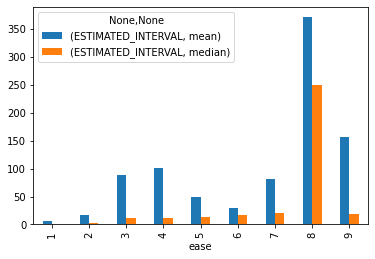

```python
tmp_df = pd.concat([X_num, Y], axis=1)
tmp_df.groupby('ease').agg({Y_COLUMN: [np.mean, np.median]}).plot.bar();
```

### 3.4.3 Pozostałe atrybuty

1. `model_type` - typ modelu `STANDARD` oznacza kartę w której rolę pytania pełni zwykły tekst z dołączoną ilustracją lub dziwiękiem bądź polem tekstowym. `CLOZE` oznacza kartę, w której treść pytania ma lukę, którą należy uzupełnić. Odpowiedź zawiera pełny tekst z wypełnioną luką.
2. `type` - Typ karty - nowa, uczona po raz pierwszy, powtarzana, uczona od nowa.
3. `queue` - Bliźniaczy do `type` - oznacza kolejkę w jakiej znajduję się aktualnie karta - nowe, uczone, powtarzae, uczone od nowa. Choć podobny do atrybutu `type`, w Anki pełni nieco inną rolę.
4. `part_of_day` - part of the day when the card was answered
5. `weekday` - day of the week
6. `question_has_cloze` - czy pytanie ma lukę. Czasem karty z modelem `STANDARD` również posiadały luki, więc ten atrybut jest dokładniejszy.
7. `question_has_type_in` - czy pytanie ma pole tekstowe do wpisania odpowiedzi
8. `question_has_type_in_cloze` - czy pole ma lukę jako pole tekstowe do wpisania w nią brakującej części tekstu
9. `question_has_sound` - czy pytanie zawiera pliki dźwiękowe
10. `answer_has_sound` - czy odpowiedź zawiera pliki dźwiękowe
11. `question_has_image` - czy pytanie zawiera ilustracje
12. `answer_has_image` - czy odpowiedź zawiera ilustracje

#### 3.4.3.1 Wpływ wartości atrybutów na atrybut wyjściowy

Dla każdego atrybutu kategorycznego wejściowego sprawdzę jak wpływa on na atrybut wyjściowy. Porównane będą mediany atrybutu `ESTIMATED_INTERVAL` pogrupowane według wartości atrybutu.

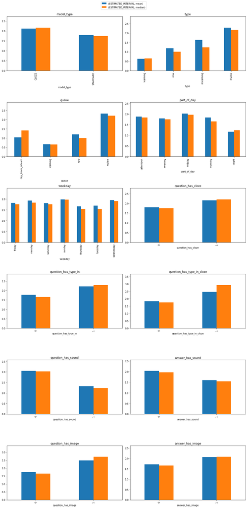

```python
columns = list(X_cat_clean.columns) + list(X_bool_clean.columns)
f, axes = plt.subplots(math.ceil(len(columns)/2), 2, figsize=(15,30))
ax = axes.ravel()

tmp_df = pd.concat([X_cat_clean, X_bool_clean, Y_clean], axis=1)

for i, attribute in enumerate(columns):
    aggregated = tmp_df.groupby(attribute).agg({Y_COLUMN: [np.mean, np.median]})

    ax[i].set_title(attribute)
    aggregated.plot.bar(ax=ax[i], legend=False)

    bottom, top = ax[i].get_ylim()
    ax[i].set_ylim(bottom, 1.2*top)

handles, labels = ax[i].get_legend_handles_labels()
f.legend(handles, labels, loc='upper center', bbox_to_anchor=[0.5, 1.02])


plt.tight_layout()
plt.show()
```

Na podstawie wykresów można stwierdzić, że pewne cechy kart sprawiają, że są one oceniane jako łatwiejsze (mają większy estymowany interwał). Różnice są zauważalne dla każdego atrybutu, dlatego wszytkie one pozostaną w zbiorze.

## 3.5 Standaryzacja

# 4. Ponowne uczenie na ulepszonym zbiorze danych

Uczenie zostanie przeprowadzone ponownie, tym razem na zbiorze wyczyszczonym, z rozkładem danych bardziej zbliżonym do normalnego i przeskalowanymi wartościami.

## 4.1 Kodowanie One-Hot

```python
X_cat_clean_one_hot = X_cat_clean.copy()

# Encode categories with One-Hot Encoder
encoder = OneHotEncoder(handle_unknown='ignore')
one_hot_categories = encoder.fit_transform(X_cat_clean_one_hot).toarray()

# Make names for new columns by concatenating category names with each of the value
new_categories = []
for i, category_name in enumerate(X_cat_clean_one_hot.columns):
    for category_value in encoder.categories_[i]:
        new_categories.append(category_name + "_" + str(category_value))

# Replace old X_cat DataFrame with a new, one-hot-encoded DataFrame
X_cat_clean_one_hot = pd.DataFrame(one_hot_categories, columns=new_categories)

display(X_cat_clean_one_hot)
```

|  | model_type_CLOZE | model_type_STANDARD | type_learning | type_new | type_relearning | type_review | queue_day_learn_relearn | queue_learning | queue_new | queue_review | ... | part_of_day_midday | part_of_day_morning | part_of_day_night | weekday_friday | weekday_monday | weekday_saturday | weekday_sunday | weekday_thursday | weekday_tuesday | weekday_wednesday |
| --- | --- | --- | --- | --- | --- | --- | --- | --- | --- | --- | --- | --- | --- | --- | --- | --- | --- | --- | --- | --- | --- |
| 0 | 0.0 | 1.0 | 0.0 | 0.0 | 0.0 | 1.0 | 0.0 | 0.0 | 0.0 | 1.0 | ... | 0.0 | 0.0 | 0.0 | 0.0 | 0.0 | 0.0 | 1.0 | 0.0 | 0.0 | 0.0 |
| 1 | 0.0 | 1.0 | 0.0 | 0.0 | 0.0 | 1.0 | 0.0 | 0.0 | 0.0 | 1.0 | ... | 0.0 | 0.0 | 0.0 | 0.0 | 0.0 | 0.0 | 1.0 | 0.0 | 0.0 | 0.0 |
| 2 | 0.0 | 1.0 | 0.0 | 0.0 | 0.0 | 1.0 | 0.0 | 0.0 | 0.0 | 1.0 | ... | 0.0 | 0.0 | 0.0 | 0.0 | 0.0 | 0.0 | 1.0 | 0.0 | 0.0 | 0.0 |
| 3 | 0.0 | 1.0 | 0.0 | 0.0 | 0.0 | 1.0 | 0.0 | 0.0 | 0.0 | 1.0 | ... | 0.0 | 0.0 | 0.0 | 0.0 | 0.0 | 0.0 | 1.0 | 0.0 | 0.0 | 0.0 |
| 4 | 0.0 | 1.0 | 0.0 | 0.0 | 0.0 | 1.0 | 0.0 | 0.0 | 0.0 | 1.0 | ... | 0.0 | 0.0 | 0.0 | 0.0 | 0.0 | 0.0 | 1.0 | 0.0 | 0.0 | 0.0 |
| ... | ... | ... | ... | ... | ... | ... | ... | ... | ... | ... | ... | ... | ... | ... | ... | ... | ... | ... | ... | ... | ... |
| 36391 | 1.0 | 0.0 | 0.0 | 0.0 | 0.0 | 1.0 | 0.0 | 0.0 | 0.0 | 1.0 | ... | 1.0 | 0.0 | 0.0 | 0.0 | 0.0 | 0.0 | 1.0 | 0.0 | 0.0 | 0.0 |
| 36392 | 1.0 | 0.0 | 0.0 | 0.0 | 0.0 | 1.0 | 0.0 | 0.0 | 0.0 | 1.0 | ... | 1.0 | 0.0 | 0.0 | 0.0 | 0.0 | 0.0 | 1.0 | 0.0 | 0.0 | 0.0 |
| 36393 | 1.0 | 0.0 | 0.0 | 0.0 | 0.0 | 1.0 | 0.0 | 0.0 | 0.0 | 1.0 | ... | 1.0 | 0.0 | 0.0 | 0.0 | 0.0 | 0.0 | 1.0 | 0.0 | 0.0 | 0.0 |
| 36394 | 0.0 | 1.0 | 0.0 | 0.0 | 0.0 | 1.0 | 0.0 | 0.0 | 0.0 | 1.0 | ... | 1.0 | 0.0 | 0.0 | 0.0 | 0.0 | 0.0 | 1.0 | 0.0 | 0.0 | 0.0 |
| 36395 | 0.0 | 1.0 | 0.0 | 0.0 | 1.0 | 0.0 | 0.0 | 1.0 | 0.0 | 0.0 | ... | 1.0 | 0.0 | 0.0 | 0.0 | 0.0 | 0.0 | 1.0 | 0.0 | 0.0 | 0.0 |

36396 rows × 22 columns

## 4.2 Połączenie zbiórów w jeden

```python
# Using .dropna(), because X_num_clean has less rows than other data frames.
# Rows with NaNs (which appear after contatenation) must be removed
X_num_clean2 = X_num_clean.copy()[NUMERICAL_COLUMNS]
XY = pd.concat([X_num_clean2, X_cat_clean_one_hot, X_bool_clean, Y_clean], axis=1).dropna()
```

## 4.3 Wyodrębnienie zbioru treningowego i testowego

```python
df_train, df_test = model_selection.train_test_split(
    XY,
    random_state=0,
    test_size=.3
)

X_train = df_train.drop(Y_COLUMN, axis=1)
X_test = df_test.drop(Y_COLUMN, axis=1)

Y_train = df_train[Y_COLUMN]
Y_test = df_test[Y_COLUMN]
```

## 4.4 Przeprowadzenie uczenia (z automatyczną standaryzacją)

- Wykorzystana zostanie funkcja `learn_predict()` z punktu 2.4 Uczenie za pomocą kilku modeli.
- Wszystkie modele zostaną opakowane w model `TransformedTargetRegressor`. Do przeskalowania wartości zostanie użyty `StandardScaler()`.

```python
models = [
    ("ARDRegression", linear_model.ARDRegression()),
    ("AdaBoostRegressor", ensemble.AdaBoostRegressor()),
    ("BaggingRegressor", ensemble.BaggingRegressor()),
    ("DecisionTreeRegressor", tree.DecisionTreeRegressor()),
    ("ElasticNet", linear_model.ElasticNet()),
    ("ElasticNetCV", linear_model.ElasticNetCV()),
    ("ExtraTreeRegressor", tree.ExtraTreeRegressor()),
    ("ExtraTreesRegressor", ensemble.ExtraTreesRegressor()),
    ("HuberRegressor", linear_model.HuberRegressor()),
    ("KNeighborsRegressor", neighbors.KNeighborsRegressor()),
    ("Lasso", linear_model.Lasso()),
    ("LassoCV", linear_model.LassoCV()),
    ("MLPRegressor", neural_network.MLPRegressor()),
    ("NuSVR", svm.NuSVR()),
    ("OrthogonalMatchingPursuit", linear_model.OrthogonalMatchingPursuit()),
    ("OrthogonalMatchingPursuitCV", linear_model.OrthogonalMatchingPursuitCV()),
    ("PLSRegression", cross_decomposition.PLSRegression()),
    ("PassiveAggressiveRegressor", linear_model.PassiveAggressiveRegressor()),
    ("RANSACRegressor", linear_model.RANSACRegressor()),
#     ("RadiusNeighborsRegressor", neighbors.RadiusNeighborsRegressor()),
    ("RandomForestRegressor", ensemble.RandomForestRegressor()),
    ("Ridge", linear_model.Ridge()),
    ("RidgeCV", linear_model.RidgeCV()),
    ("SGDRegressor", linear_model.SGDRegressor()),
    ("SVR", svm.SVR()),
    ("TheilSenRegressor", linear_model.TheilSenRegressor()),
]
```

```python
def learn_predict(models_, X_train_, X_test_, Y_train_, Y_test_):
    results_test_ = pd.DataFrame(columns=['method', 'r2_score', 'explained_variance', 'MSE'])
    results_train_ = pd.DataFrame(columns=['method', 'r2_score', 'explained_variance','MSE'])

    for name, model in models_:
        start = time.time()
        model.fit(X_train_.copy(), Y_train_.copy())
        print(name + ": " + str(time.time()-start) + "s")
        predictions_test = model.predict(X_test_.copy())
        predictions_train = model.predict(X_train_.copy())

        results_test_ = results_test_.append({
            'method': name,
            'r2_score': metrics.r2_score(Y_test_, predictions_test),
            'explained_variance': metrics.explained_variance_score(Y_test_, predictions_test),
            'MSE': metrics.mean_squared_error(Y_test_, predictions_test),
        }, ignore_index=True)

        results_train_ = results_train_.append({
            'method': name,
            'r2_score': metrics.r2_score(Y_train_, predictions_train),
            'explained_variance': metrics.explained_variance_score(Y_train_, predictions_train),
            'MSE': metrics.mean_squared_error(Y_train_, predictions_train),
        }, ignore_index=True)

    return results_test_, results_train_
```

```python
def wrap_model(model):
    return compose.TransformedTargetRegressor(
        regressor=model,
        transformer=StandardScaler()
    )

wrapped_models = [(name, wrap_model(model)) for name, model in models]

results_test_2, results_train_2 = learn_predict(wrapped_models, X_train, X_test, Y_train, Y_test)
```

```
ARDRegression: 0.21312403678894043s
AdaBoostRegressor: 1.507802963256836s
BaggingRegressor: 0.8475246429443359s
DecisionTreeRegressor: 0.14535284042358398s
ElasticNet: 0.008193016052246094s
ElasticNetCV: 0.4608931541442871s
ExtraTreeRegressor: 0.11455702781677246s
ExtraTreesRegressor: 5.898248195648193s
```

```
HuberRegressor: 0.3972587585449219s
KNeighborsRegressor: 0.1621851921081543s
Lasso: 0.00655055046081543s
LassoCV: 0.9960918426513672s
MLPRegressor: 11.511520147323608s
NuSVR: 40.490647077560425s
OrthogonalMatchingPursuit: 0.009263753890991211s
OrthogonalMatchingPursuitCV: 0.06879734992980957s
PLSRegression: 0.01587677001953125s
PassiveAggressiveRegressor: 0.06117367744445801s
RANSACRegressor: 0.1872236728668213s
RandomForestRegressor: 8.388444662094116s
Ridge: 0.016117334365844727s
RidgeCV: 0.07169890403747559s
SGDRegressor: 0.09325194358825684s
SVR: 18.098540782928467s
TheilSenRegressor: 4.74749231338501s
```

```python
pd.options.display.float_format = '{:,.4f}'.format
display(HTML("<hr><h2>Test:</h2>"))
display(results_test_2.sort_values(["r2_score", "explained_variance", "MSE"], ascending=False))
display(HTML("<hr><h2>Train:</h2>"))
display(results_train_2.sort_values(["r2_score", "explained_variance", "MSE"], ascending=False))
```

Test:

|  | method | r2_score | explained_variance | MSE |
| --- | --- | --- | --- | --- |
| 7 | ExtraTreesRegressor | 0.9640 | 0.9640 | 0.0505 |
| 19 | RandomForestRegressor | 0.9613 | 0.9613 | 0.0543 |
| 2 | BaggingRegressor | 0.9576 | 0.9576 | 0.0596 |
| 12 | MLPRegressor | 0.9495 | 0.9497 | 0.0709 |
| 3 | DecisionTreeRegressor | 0.9326 | 0.9326 | 0.0947 |
| 6 | ExtraTreeRegressor | 0.9313 | 0.9313 | 0.0964 |
| 23 | SVR | 0.9019 | 0.9023 | 0.1378 |
| 13 | NuSVR | 0.9013 | 0.9020 | 0.1385 |
| 9 | KNeighborsRegressor | 0.8939 | 0.8939 | 0.1489 |
| 21 | RidgeCV | 0.8344 | 0.8344 | 0.2325 |
| 0 | ARDRegression | 0.8344 | 0.8344 | 0.2325 |
| 20 | Ridge | 0.8344 | 0.8344 | 0.2325 |
| 11 | LassoCV | 0.8343 | 0.8343 | 0.2327 |
| 5 | ElasticNetCV | 0.8341 | 0.8341 | 0.2329 |
| 22 | SGDRegressor | 0.8331 | 0.8336 | 0.2343 |
| 24 | TheilSenRegressor | 0.8283 | 0.8284 | 0.2410 |
| 8 | HuberRegressor | 0.8174 | 0.8192 | 0.2563 |
| 15 | OrthogonalMatchingPursuitCV | 0.8127 | 0.8128 | 0.2629 |
| 14 | OrthogonalMatchingPursuit | 0.8031 | 0.8031 | 0.2764 |
| 1 | AdaBoostRegressor | 0.7782 | 0.7788 | 0.3113 |
| 17 | PassiveAggressiveRegressor | 0.7621 | 0.8100 | 0.3340 |
| 16 | PLSRegression | 0.7003 | 0.7003 | 0.4208 |
| 4 | ElasticNet | 0.2568 | 0.2570 | 1.0433 |
| 10 | Lasso | -0.0002 | 0.0000 | 1.4042 |
| 18 | RANSACRegressor | -20,882,669,612,489,011,200.0000 | -20,880,718,143,513,001,984.0000 | 29,318,136,113,339,105,280.0000 |

Train:

|  | method | r2_score | explained_variance | MSE |
| --- | --- | --- | --- | --- |
| 7 | ExtraTreesRegressor | 1.0000 | 1.0000 | 0.0000 |
| 3 | DecisionTreeRegressor | 1.0000 | 1.0000 | 0.0000 |
| 6 | ExtraTreeRegressor | 1.0000 | 1.0000 | 0.0000 |
| 19 | RandomForestRegressor | 0.9948 | 0.9948 | 0.0073 |
| 2 | BaggingRegressor | 0.9925 | 0.9925 | 0.0104 |
| 12 | MLPRegressor | 0.9627 | 0.9629 | 0.0520 |
| 9 | KNeighborsRegressor | 0.9291 | 0.9291 | 0.0987 |
| 23 | SVR | 0.9071 | 0.9074 | 0.1294 |
| 13 | NuSVR | 0.9066 | 0.9071 | 0.1301 |
| 21 | RidgeCV | 0.8347 | 0.8347 | 0.2301 |
| 20 | Ridge | 0.8347 | 0.8347 | 0.2301 |
| 0 | ARDRegression | 0.8347 | 0.8347 | 0.2302 |
| 11 | LassoCV | 0.8343 | 0.8343 | 0.2308 |
| 5 | ElasticNetCV | 0.8341 | 0.8341 | 0.2310 |
| 22 | SGDRegressor | 0.8334 | 0.8337 | 0.2320 |
| 24 | TheilSenRegressor | 0.8270 | 0.8270 | 0.2409 |
| 8 | HuberRegressor | 0.8189 | 0.8202 | 0.2522 |
| 15 | OrthogonalMatchingPursuitCV | 0.8111 | 0.8111 | 0.2631 |
| 14 | OrthogonalMatchingPursuit | 0.8019 | 0.8019 | 0.2759 |
| 1 | AdaBoostRegressor | 0.7728 | 0.7735 | 0.3163 |
| 17 | PassiveAggressiveRegressor | 0.7622 | 0.8076 | 0.3312 |
| 16 | PLSRegression | 0.6960 | 0.6960 | 0.4233 |
| 4 | ElasticNet | 0.2562 | 0.2562 | 1.0357 |
| 10 | Lasso | 0.0000 | 0.0000 | 1.3925 |
| 18 | RANSACRegressor | -27,070,582,679,903,166,464.0000 | -27,067,330,046,622,203,904.0000 | 37,696,256,153,607,634,944.0000 |

## 4.5 Obserwacje

1. Po korekcie danych udało się uzysać lepsze wyniki: większy współczynnik determinacji $R^2$, mniejszy błąd średniokwadratowy
2. Zmienił się również "ranking" modeli. Dużą poprawę zaobserwowane np. dla `KNeighborsRegressor`.
3. Uczenie przeprowadzono na danych po transformacji Boxa-Coxa. Aby otrzymać prawdziwą i użyteczną wartość interwału, należałoby odwrócić transformację.

# 5. Dostrajanie modeli

Kolejnym etapem mojej pracy jest dostrojenie modeli, tak aby dawały jeszcze lepsze wyniki. Do tej pory wszystkie uruchamiano z wartościami domyślnymi. Teraz, wybiorę 10 najlepszych modeli i dla każdego z nich postaram się znaleźć jak najlepsze hiperparametry.

```python
# NOTE that classes are now used instead of objects
best_models = [
    ("ExtraTreesRegressor", ensemble.ExtraTreesRegressor),
    ("RandomForestRegressor", ensemble.RandomForestRegressor),
    ("BaggingRegressor", ensemble.BaggingRegressor),
    ("MLPRegressor", neural_network.MLPRegressor),
    ("ExtraTreeRegressor", tree.ExtraTreeRegressor),
    ("DecisionTreeRegressor", tree.DecisionTreeRegressor),
    ("SVR", svm.SVR),
    ("NuSVR", svm.NuSVR),
    ("KNeighborsRegressor", neighbors.KNeighborsRegressor),
    ("Ridge", linear_model.Ridge),
]
```

## 5.1 Wybór parametrów do przetestowania

Dla każdego modelu wybrane zostanie kilka najistotniejszych parametrów i ich wartości, które zostaną przetestowane i posłużą do wybrania najlepszego estymatora

### 5.1.1 ExtraTreesRegressor

Meta-estymator, który wykorzysuje wiele losowych drzew decyzjnych.

Parametry, które będą dostrajane:

- `n_estimators` - liczba drzew decyzyjnych
- `max_featues` - liczba atrybutów wykorzystywanych do wykonania najlepszego podziału węzłów

### 5.1.2 RandomForestRegressor

Meta-estymator wykorzysujacy wiele losowych drzew decyzyjnych

Parametry, które będą dostrajane:

- `n_estimators` - liczba drzew decyzyjnych
- `max_featues` - liczba atrybutów wykorzystywanych do wykonania najlepszego podziału węzłów

### 5.1.3 BaggingRegressor

Kolejny meta-estymator, wykorzystujacy wiele innych estymatorów.

Parametry, które będą dostrajane:

- `base_estimator` - bazowy estymator wykorzystywany w tej metodzie
- `n_estimators` - liczba wykorzystanych bazowych estmatorów
- `max_samples` - Liczba/ułamek próbek do pobrania z X w celu uczenia każdego bazowego estymatora
- `max_featues` - Liczba/ułamek atrybutów do pobrania z X w celu uczenia każdego bazowego estymatora

### 5.1.4 MLPRegressor

Regresor oparty o "perceptron wielowarstwowy" - najpopularniejszy typ sztucznych sieci neuronowych.

Parametry, które będą dostrajane:

- `hidden_layer_sizes` - liczba neuronów w warstwie ukrytej
- `activation` - funkcja aktywacji
- `solver` - metoda optymalizacji wag

### 5.1.5 ExtraTreeRegressor

Regresor oparty o drzewo decyzyjne. Od `DecisionTreeRegressor` różni się sposobem w jaki dzieli próbki na dwie grupy.

Parametry, które będą dostrajane:

- `criterion` - funkcja mierząca jakość podziału
- `max_features` - liczba atrybutów wykorzystywana w procesie dzielenia próbek na dwie grupy

### 5.1.6 DecisionTreeRegressor

Drzewo decyzyjne

Parametry, które będą dostrajane:

- `criterion` - funkcja mierząca jakość podziału
- `max_features` - liczba atrybutów wykorzystywana w procesie dzielenia próbek na dwie grupy

### 5.1.7 SVR

Maszyna wektorów nośnych - dla zagadnienia regresji

Parametry, które będą dostrajane:

- `kernel` - funkcja jądra
- `C` - parametr regularyzacji
- `gamma` - parametr określający jak duży wpływ na uczenie ma pojedycza próbka

### 5.1.8 NuSVR

Model podobny do SVR, ale wykorzystujacy dodatkowy parametr `nu` kontrolujący liczbę wectorów nośnych.

Parametry, które będą dostrajane:

- `nu` - liczba wektorów nośnych
- `kernel` - funkcja jądra
- `C` - parametr regularyzacji
- `gamma` - parametr określający jak duży wpływ na uczenie ma pojedycza próbka

### 5.1.9 KNeighborsRegressor

Regresor oparty o metodę nabliższych sąsiadów

Parametry, które będą dostrajane

- `n_neighbors` - liczba najbliższych sąsiadów
- `algorithm` - algorytm obliczania najbliższych sąsiadów

### 5.1.10 Ridge

Regresja liniowa z regularyzacją Tichonowa

Parametry, które będą dostrajane:

- `alpha` - współczynnik regularyzacji
- `fit_intercept` - czy "linia trendu" może przecinać oś Y w innym miejscu niż punkt (0,0)
- `solver` - Solver

## 5.2 Poszukiwanie najlepszych parametrów dla każdego estymatora

#### KNeighborsRegressor

```python
from sklearn.model_selection import cross_val_score

algorithms = ["ball_tree", "kd_tree", "brute"]
k_range = range(1, 50, 3)
weights = ["uniform", "distance"]

params_list = []
for algorithm in algorithms:
    for weight in weights:
        for k in k_range:
            params_list.append({
                "algorithm": algorithm,
                "n_neighbors": k,
                "weights": weight
            })

results = {
    weights[0]: {
        'x': [],      # n_neighbors
        'y': [],      # algorithm
        'score': [],  # score of the model
        'std': []     # Standard deviation
    },
    weights[1]: {
        'x': [],      # n_neighbors
        'y': [],      # algorithm
        'score': [],  # score of the model
        'std': [],    # Standard deviation
    },
}
for i, params in enumerate(params_list):
    print(f"[{i+1}/{len(params_list)}]")

    weights = params["weights"]
    algorithm = params["algorithm"]
    n_neighbors = params["n_neighbors"]
    print(f"Testing KNeighborsRegressor(n_neighbors={n_neighbors}, algorithm={algorithm}, weights={weights})")

    model = neighbors.KNeighborsRegressor(
        n_neighbors=n_neighbors,
        algorithm=algorithm,
        weights=weights
    )
    scores = cross_val_score(model, X_train, Y_train, cv=3)
    accuracy = scores.mean()
    std = scores.std()

    # Save results:
    results[weights]['x'].append(n_neighbors)
    results[weights]['y'].append(algorithm)
    results[weights]['score'].append(accuracy)
    results[weights]['std'].append(std)

    print("Accuracy: %0.2f (+/- %0.2f)" % (scores.mean(), scores.std() * 2))
```

```
[1/102]
Testing KNeighborsRegressor(n_neighbors=1, algorithm=ball_tree, weights=uniform)
Accuracy: 0.83 (+/- 0.00)
[2/102]
Testing KNeighborsRegressor(n_neighbors=4, algorithm=ball_tree, weights=uniform)
Accuracy: 0.87 (+/- 0.00)
[3/102]
Testing KNeighborsRegressor(n_neighbors=7, algorithm=ball_tree, weights=uniform)
Accuracy: 0.88 (+/- 0.00)
[4/102]
Testing KNeighborsRegressor(n_neighbors=10, algorithm=ball_tree, weights=uniform)
Accuracy: 0.87 (+/- 0.00)
[5/102]
Testing KNeighborsRegressor(n_neighbors=13, algorithm=ball_tree, weights=uniform)
Accuracy: 0.87 (+/- 0.01)
[6/102]
Testing KNeighborsRegressor(n_neighbors=16, algorithm=ball_tree, weights=uniform)
Accuracy: 0.87 (+/- 0.00)
[7/102]
Testing KNeighborsRegressor(n_neighbors=19, algorithm=ball_tree, weights=uniform)
Accuracy: 0.87 (+/- 0.01)
[8/102]
Testing KNeighborsRegressor(n_neighbors=22, algorithm=ball_tree, weights=uniform)
Accuracy: 0.86 (+/- 0.01)
[9/102]
Testing KNeighborsRegressor(n_neighbors=25, algorithm=ball_tree, weights=uniform)
Accuracy: 0.86 (+/- 0.01)
[10/102]
Testing KNeighborsRegressor(n_neighbors=28, algorithm=ball_tree, weights=uniform)
Accuracy: 0.86 (+/- 0.00)
[11/102]
Testing KNeighborsRegressor(n_neighbors=31, algorithm=ball_tree, weights=uniform)
Accuracy: 0.86 (+/- 0.01)
[12/102]
Testing KNeighborsRegressor(n_neighbors=34, algorithm=ball_tree, weights=uniform)
Accuracy: 0.86 (+/- 0.01)
[13/102]
Testing KNeighborsRegressor(n_neighbors=37, algorithm=ball_tree, weights=uniform)
Accuracy: 0.85 (+/- 0.00)
[14/102]
```

[output cut: 251 more lines]

```
[98/102]
Testing KNeighborsRegressor(n_neighbors=37, algorithm=brute, weights=distance)
Accuracy: 0.87 (+/- 0.00)
[99/102]
Testing KNeighborsRegressor(n_neighbors=40, algorithm=brute, weights=distance)
Accuracy: 0.86 (+/- 0.00)
[100/102]
Testing KNeighborsRegressor(n_neighbors=43, algorithm=brute, weights=distance)
Accuracy: 0.86 (+/- 0.00)
[101/102]
Testing KNeighborsRegressor(n_neighbors=46, algorithm=brute, weights=distance)
Accuracy: 0.86 (+/- 0.00)
[102/102]
Testing KNeighborsRegressor(n_neighbors=49, algorithm=brute, weights=distance)
Accuracy: 0.86 (+/- 0.00)
```

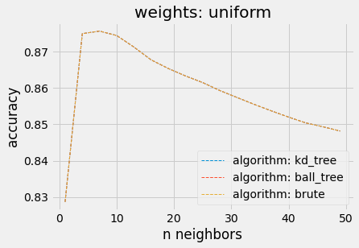

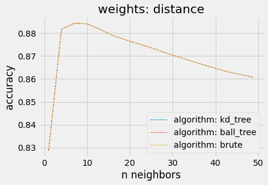

```
Best score (0.88437):
KNeighborsRegressor(n_neighbors=7, algorithm=ball_tree, weights=distance)
```

```python
from mpl_toolkits.mplot3d import Axes3D
from collections import defaultdict
plt.style.use('fivethirtyeight')
best_score = {
    'weights': None,
    'algorithm': None,
    'n_neighbors': None,
    'value': 0
}
for weights, scores_data in results.items():
    xs = defaultdict(list)
    scores = defaultdict(list)
    algorithms_set = set()
    for i, algorithm in enumerate(scores_data['y']):
        scores[algorithm].append(scores_data['score'][i])
        xs[algorithm].append(scores_data['x'][i])
        algorithms_set.add(algorithm)

        if scores_data['score'][i] > best_score['value']:
            best_score['weights'] = weights
            best_score['algorithm'] = algorithm
            best_score['n_neighbors'] = scores_data['x'][i]
            best_score['value'] = scores_data['score'][i]

    for algorithm in algorithms_set:
        plt.plot(xs[algorithm], scores[algorithm], label="algorithm: " + algorithm, linewidth=1, linestyle="dashed")
    plt.title("weights: " + weights)
    plt.legend()
    plt.xlabel("n neighbors")
    plt.ylabel("accuracy")
    plt.show()

print("Best score (%0.5f):" % best_score['value'])
print(f"KNeighborsRegressor("
      f"n_neighbors={best_score['n_neighbors']}, "
      f"algorithm={best_score['algorithm']}, "
      f"weights={best_score['weights']})")
```

#### MLPRegressor

```python
from sklearn.model_selection import cross_val_score

activations = ['logistic', 'tanh', 'relu']
nodes_per_layer_choices = [10, 20, 30, 40, 50, 100, 150, 200, 250, 300]
n_hidden_layer_choices = [1, 2, 3, 4, 5, 6]

params_list = []
for activation in activations:
    for nodes_per_layer in nodes_per_layer_choices:
        for n_hidden_layer in n_hidden_layer_choices:
            params_list.append({
                "activation": activation,
                "nodes_per_layer": nodes_per_layer,
                "n_hidden_layers": n_hidden_layer
            })

results = {
    activations[0]: {
        'x': [],      # nodes per layer
        'y': [],      # number of hidden layers
        'score': [],  # score of the model
        'std': []     # Standard deviation
    },
    activations[1]: {
        'x': [],      # nodes per layer
        'y': [],      # number of hidden layers
        'score': [],  # score of the model
        'std': [],    # Standard deviation
    },
    activations[2]: {
        'x': [],  # nodes per layer
        'y': [],  # number of hidden layers
        'score': [],  # score of the model
        'std': [],    # Standard deviation
    },
}
for i, params in enumerate(params_list):
    print(f"[{i+1}/{len(params_list)}]")

    hidden_layer_sizes = (params["nodes_per_layer"], ) * params["n_hidden_layers"]
    activation = params["activation"]
    print(f"Testing MLPRegressor(activation={activation}, hidden_layer_sizes={hidden_layer_sizes})")

    model = neural_network.MLPRegressor(
        activation=activation,
        hidden_layer_sizes=hidden_layer_sizes,
        max_iter=2000
    )
    scores = cross_val_score(model, X_train, Y_train, cv=3)
    accuracy = scores.mean()
    std = scores.std()

    # Save results:
    results[activation]['x'].append(params["nodes_per_layer"])
    results[activation]['y'].append(params["n_hidden_layers"])
    results[activation]['score'].append(accuracy)
    results[activation]['std'].append(std)

    print("Accuracy: %0.2f (+/- %0.2f)" % (scores.mean(), scores.std() * 2))
```

```
[1/180]
Testing MLPRegressor(activation=logistic, hidden_layer_sizes=(10,))
Accuracy: 0.93 (+/- 0.01)
[2/180]
Testing MLPRegressor(activation=logistic, hidden_layer_sizes=(10, 10))
Accuracy: 0.93 (+/- 0.01)
[3/180]
Testing MLPRegressor(activation=logistic, hidden_layer_sizes=(10, 10, 10))
Accuracy: 0.93 (+/- 0.01)
[4/180]
Testing MLPRegressor(activation=logistic, hidden_layer_sizes=(10, 10, 10, 10))
Accuracy: 0.93 (+/- 0.00)
[5/180]
Testing MLPRegressor(activation=logistic, hidden_layer_sizes=(10, 10, 10, 10, 10))
Accuracy: 0.93 (+/- 0.00)
[6/180]
Testing MLPRegressor(activation=logistic, hidden_layer_sizes=(10, 10, 10, 10, 10, 10))
Accuracy: 0.93 (+/- 0.00)
[7/180]
Testing MLPRegressor(activation=logistic, hidden_layer_sizes=(20,))
Accuracy: 0.94 (+/- 0.00)
[8/180]
Testing MLPRegressor(activation=logistic, hidden_layer_sizes=(20, 20))
Accuracy: 0.94 (+/- 0.00)
[9/180]
Testing MLPRegressor(activation=logistic, hidden_layer_sizes=(20, 20, 20))
Accuracy: 0.94 (+/- 0.00)
[10/180]
Testing MLPRegressor(activation=logistic, hidden_layer_sizes=(20, 20, 20, 20))
Accuracy: 0.94 (+/- 0.00)
[11/180]
Testing MLPRegressor(activation=logistic, hidden_layer_sizes=(20, 20, 20, 20, 20))
Accuracy: 0.94 (+/- 0.00)
[12/180]
Testing MLPRegressor(activation=logistic, hidden_layer_sizes=(20, 20, 20, 20, 20, 20))
Accuracy: 0.94 (+/- 0.00)
[13/180]
Testing MLPRegressor(activation=logistic, hidden_layer_sizes=(30,))
Accuracy: 0.94 (+/- 0.00)
[14/180]
```

[output cut: 485 more lines]

```
[176/180]
Testing MLPRegressor(activation=relu, hidden_layer_sizes=(300, 300))
Accuracy: 0.95 (+/- 0.00)
[177/180]
Testing MLPRegressor(activation=relu, hidden_layer_sizes=(300, 300, 300))
Accuracy: 0.95 (+/- 0.00)
[178/180]
Testing MLPRegressor(activation=relu, hidden_layer_sizes=(300, 300, 300, 300))
Accuracy: 0.95 (+/- 0.00)
[179/180]
Testing MLPRegressor(activation=relu, hidden_layer_sizes=(300, 300, 300, 300, 300))
Accuracy: 0.95 (+/- 0.00)
[180/180]
Testing MLPRegressor(activation=relu, hidden_layer_sizes=(300, 300, 300, 300, 300, 300))
Accuracy: 0.95 (+/- 0.00)
```

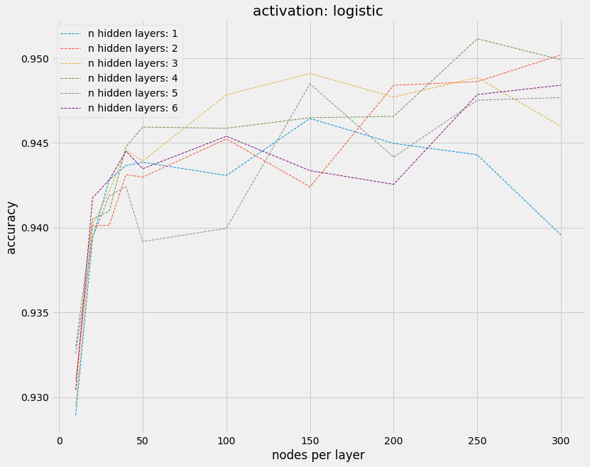

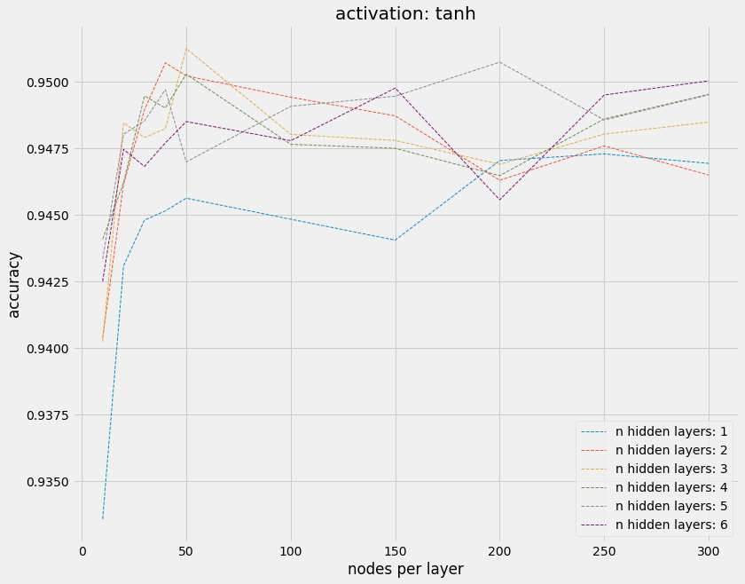

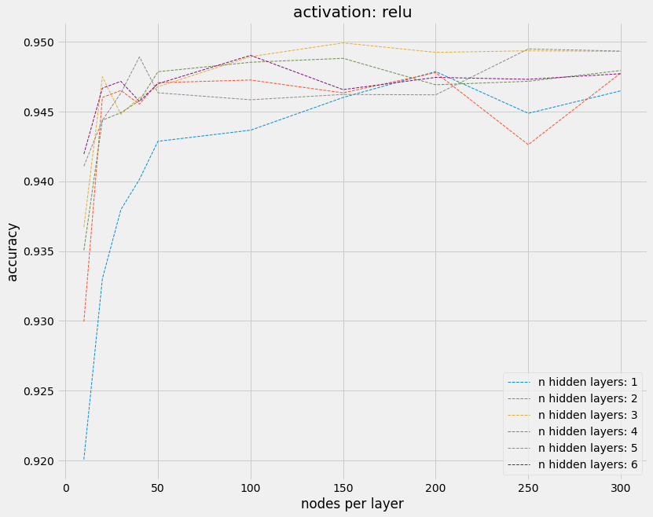

```
Best score (0.95125):
MLPRegressor(activation='tanh', hidden_layer_sizes=(50, 50, 50))
```

```python
from mpl_toolkits.mplot3d import Axes3D
from collections import defaultdict
plt.style.use('fivethirtyeight')
best_score = {
    'activation': None,
    'n_hidden_layers': None,
    'nodes_per_layer': None,
    'value': 0
}
for activation, scores_data in results.items():
    xs = defaultdict(list)
    scores = defaultdict(list)
    n_hidden_layers_set = set()
    for i, n_hidden_layers in enumerate(scores_data['y']):
        scores[n_hidden_layers].append(scores_data['score'][i])
        xs[n_hidden_layers].append(scores_data['x'][i])
        n_hidden_layers_set.add(n_hidden_layers)

        if scores_data['score'][i] > best_score['value']:
            best_score['activation'] = activation
            best_score['n_hidden_layers'] = n_hidden_layers
            best_score['nodes_per_layer'] = scores_data['x'][i]
            best_score['value'] = scores_data['score'][i]

    plt.figure(figsize=(12,10))
    for n_hidden_layers in n_hidden_layers_set:
        plt.plot(xs[n_hidden_layers], scores[n_hidden_layers], label="n hidden layers: " + str(n_hidden_layers), linewidth=1, linestyle="dashed")
    plt.title("activation: " + activation)
    plt.legend()
    plt.xlabel("nodes per layer")
    plt.ylabel("accuracy")
    plt.show()

print("Best score (%0.5f):" % best_score['value'])
print(f"MLPRegressor("
      f"activation='{best_score['activation']}', "
      f"hidden_layer_sizes={(best_score['nodes_per_layer'], ) * best_score['n_hidden_layers']})"
     )
```